# Seurat workflow of the integrated D05 ctrl, D07 ctrl and ctrl 1 (day 10)

Fabio Sacher

06.02.2023

Render this script with > sbatch ~/spinal_cord_paper/scripts/Seurat_Gg_NT_int_array.sh

# load the data

the following workflow is based on: - [https://github.com/satijalab/seurat/issues/1500] Cell cycle regression - [https://github.com/satijalab/seurat/issues/1836] General workflow - [https://github.com/satijalab/seurat/issues/2590] Integrate all features (although used in the integration script)

```r
library(Seurat)
library(dplyr)
library(Rtsne)
library(RColorBrewer)
library(tidyr)
library(ggplot2)
library(gridExtra)
library(patchwork)
library(cowplot)
library(ggdendro)
```

```r
gnames <- modplots::gnames
# load the integrated seurat
my.int <- readRDS(file = \~/spinal_cord_paper/data/Gg_devel_integrated_060223.rds\)

my.int@project.name <- \Gg_devel_int\

my.int
```

# inspect

We order the plot by nCount_RNA to prevent overplotting of the last sample (default order is the group.by ident).

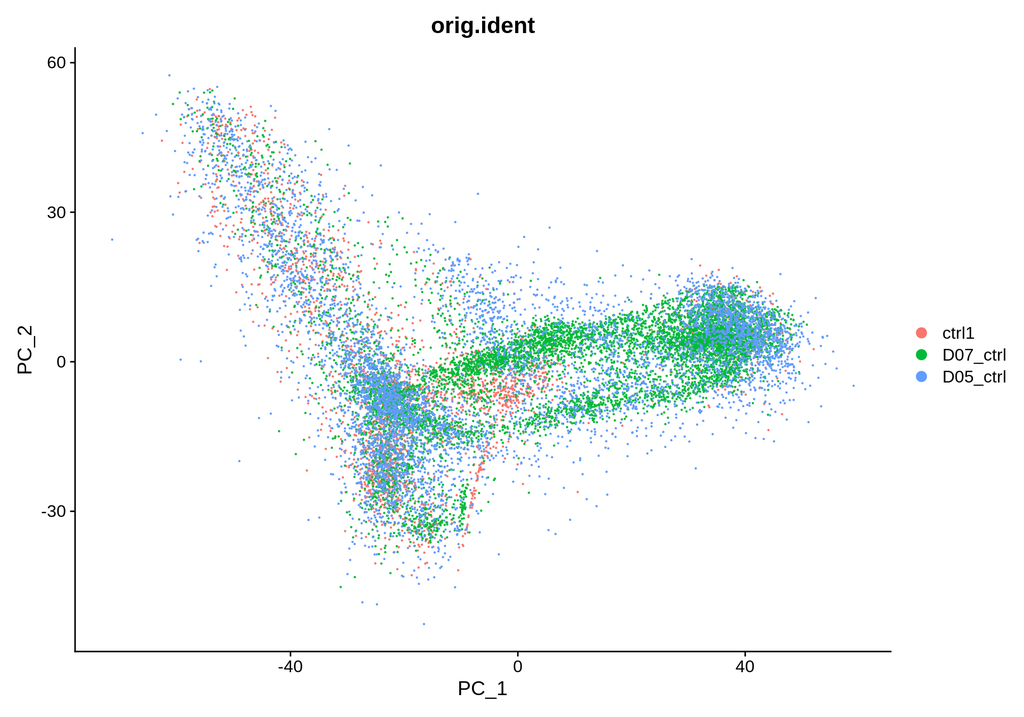

```r
# have a look at the PC and the previously calculated UMAP
PCAPlot(
  my.int,
  group.by = \orig.ident\,
  order = \nCount_RNA\
  )
```

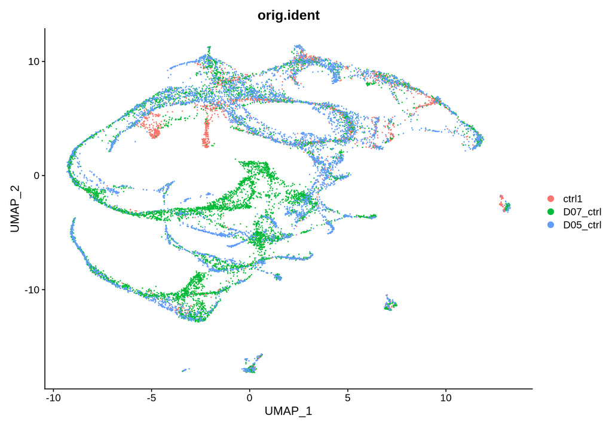

```r
DimPlot(
  my.int,
  reduction = \umap\,
  group.by = \orig.ident\,
  order = \nCount_RNA\
  )
```

# cell cycle scoring

Now we can score the cell cycle stage, using Seurats function. For this wee need the ortholog of the distributed cell stage marker lists.

We do the CC.difference calculation at this stage - and not prior to integration - based on the suggestion from: [https://github.com/satijalab/seurat/issues/1500]

```r
# Load the orhtology table
ortho_gg_mm_v102 <- readRDS(\~/spinal_cord_paper/data/ortho_gg_mm_v102.rds\)

colnames(ortho_gg_mm_v102) <- c(
  \GG_gene_ID\,
  \GG_gene_Name\,
  \MM_gene_ID\,
  \MM_gene_Name\,
  \ortho_conf\,
  \homolog_type\
)

# A list of cell cycle markers, from Tirosh et al, 2015, is loaded with Seurat.  We can
# segregate this list into markers of G2/M phase and markers of S phase
s.genes <- ortho_gg_mm_v102 %>%
  dplyr::mutate(MM_gene_Name = toupper(MM_gene_Name)) %>%
  dplyr::filter(MM_gene_Name %in% cc.genes$s.genes) %>%
  dplyr::arrange(match(MM_gene_Name, cc.genes$s.genes)) %>%
  dplyr::pull(GG_gene_ID)

g2m.genes <- ortho_gg_mm_v102 %>%
  dplyr::mutate(MM_gene_Name = toupper(MM_gene_Name)) %>%
  dplyr::filter(MM_gene_Name %in% cc.genes$g2m.genes) %>%
  dplyr::arrange(match(MM_gene_Name, cc.genes$g2m.genes)) %>%
  dplyr::pull(GG_gene_ID)

t0 <- Sys.time()
my.int <- CellCycleScoring(
  my.int,
  s.features = s.genes,
  g2m.features = g2m.genes,
  set.ident = TRUE
  )
paste0(\Seurats CC scoring took \, Sys.time() - t0, \ seconds to run.\)

my.int$CC.Difference.seurat <- my.int$S.Score - my.int$G2M.Score
# view cell cycle scores and phase assignments
head(my.int[[]])

rm(t0, s.genes, g2m.genes)
```

# rescale integrated assay

We rescale the data to regress out the CC.difference

```r
all_genes <- rownames(my.int)

my.int <- ScaleData(
  my.int,
  features = all_genes,
  vars.to.regress = \CC.Difference.seurat\
)
```

# PCA

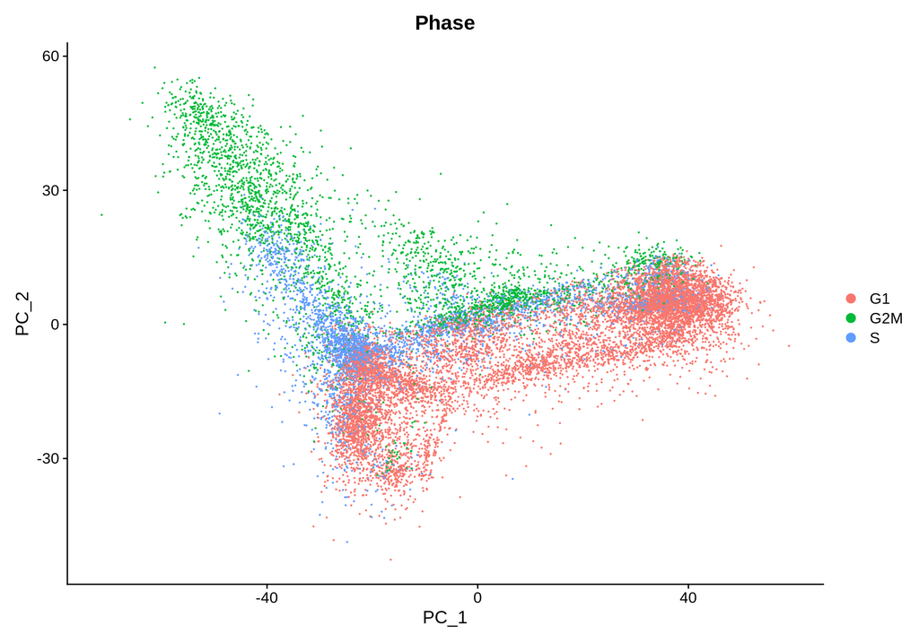

```r
PCAPlot(my.int, group.by = \Phase\)
```

# Dim Reduction

```r
# Get the tSNE function
source(\~/Software/FIt-SNE-master/fast_tsne.R\)

my.tsne = fftRtsne(my.int@reductions$pca@cell.embeddings[,my.dimensions],
                   max_iter = 1000,
                   learning_rate =  round(dim(my.int)[2]/12),
                   initialization =(my.int@reductions$pca@cell.embeddings[,1:2]/my.int@reductions$pca@stdev[1])*0.0001,
                   perplexity_list = c(30, round(dim(my.int)[2]/100)),
                   fast_tsne_path=\~/Software/FIt-SNE-master/bin/fast_tsne\)

colnames(my.tsne) = c(\tsne_1\, \tsne_2\)
rownames(my.tsne) = colnames(my.int)

my.int[[\tsne\]] = CreateDimReducObject(embeddings = my.tsne, key = \tsne_\, assay = DefaultAssay(my.int), global = T)
```